# GLM - Part I: Logistic Regression

Spring 2026

## Book chapters

- **An Introduction to Statistical Learning (ISLR)**: Chapter 4 (Classification). Key sections:
  - **4.2** Why Not Linear Regression?
  - **4.3** Logistic Regression (The Logistic Model, Estimating coefficients, Making Predictions, Multiple Logistic Regression)
- **The R Book (Crawley)**: Chapter 13 (Generalized Linear Models). Key sections:
  - **Introduction to GLMs** (Error structures, Linear Predictors, and Link functions)
  - **Binomial Data** (Binomial Errors for grouped data)
  - **Binary Response Variables** (Modeling individual 0/1 outcomes)

## GLM’s - What for?

- A bigger class of linear models
- Most single-response linear models are GLM’s
- Allows non-normally distributed response
  - Binary response
  - Binomial response
  - Count response
  - Skewed data - Gamma response
  - Multinomial response
  - And more…

## Today’s topics

- Motivating examples: why linear regression fails for binary data
- Logistic regression (binary or Binomial response)
- Estimation of parameters and Inference
- Application to data examples
- Binary classification revisited

## Recall linear regression

From our earlier lectures, we have observed data with a continuous response \(y_i\) and predictors \(x_{i1}, \dots, x_{ip}\).

The multiple linear regression model is: \[ \mu(\boldsymbol{x}_i) = E(y_i) = \beta_0 + \beta_1 x_{i1} + \dots + \beta_p x_{ip} \]

where the observations \(y_i\) are typically assumed to be normally distributed around the mean \(\mu(\boldsymbol{x}_i)\) with some variance \(\sigma^2\): \[ y_i \sim N(\mu(\boldsymbol{x}_i), \sigma^2) \]

What happens if the response variable \(y_i\) is **binary**, meaning it can only take values 0 or 1?

## What if the response is binary?

Imagine we want to predict if a client will default on a loan ( \(y \in \{0,1\}\)) based on their account Balance (\(x\in R\)).

If we fit a simple linear regression model: \[ E(y_i) = \beta_0 + \beta_1 x_{i1} \]

We want the expected value \(E(y_i)\) to represent the **probability** \(P(y_i = 1)\), right? However, a straight line can predict probabilities less than 0 or greater than 1, which is not possible!

## What if the response is binary? (Data)

```
##   default student   balance    income
## 1      No      No  729.5265 44361.625
## 2      No     Yes  817.1804 12106.135
## 3      No      No 1073.5492 31767.139
## 4      No      No  529.2506 35704.494
## 5      No      No  785.6559 38463.496
## 6      No     Yes  919.5885  7491.559
```

## What if the response is binary? (Plot)

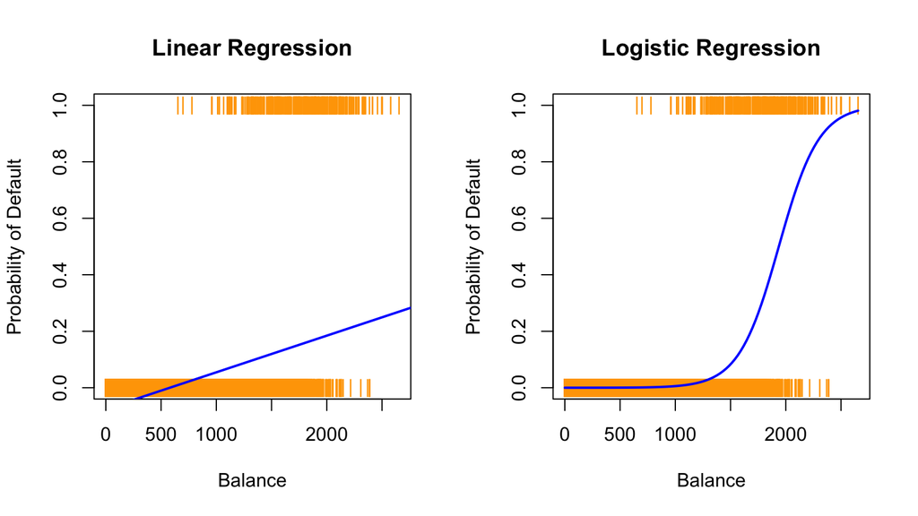

## Modeling the Response

In Linear Regression, we assumed the continuous response \(y_i\) followed a **Normal Distribution** centered around its mean \(\mu_i\): \[ y_i \sim N(\mu_i, \sigma^2) \]

For a binary response, the data can only be \(0\) or \(1\). This perfectly matches the **Bernoulli Distribution**!

The Bernoulli distribution describes a single trial that results in a “success” (\(y=1\)) with probability \(p_i\), or “failure” (\(y=0\)) with probability \(1-p_i\): \[ y_i \sim \text{Bernoulli}(p_i) \]

Our “mean” prediction is now simply the probability: \(E(y_i) = p_i\).

## Normal vs Bernoulli Distribution

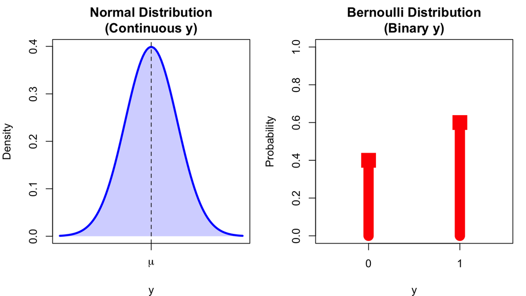

## Solution: Logistic regression

In logistic regression, we model the probability \(p_i = p(\boldsymbol{x}_i) = P(y_i = 1|\boldsymbol{x}_i)\) directly, ensuring it stays between 0 and 1.

Instead of a straight line, we use the **logistic function** (or sigmoid function):

\[ p(\boldsymbol{x}_i) = \frac{e^{ \beta_0 + \beta_1 x_{i1} + \dots + \beta_p x_{ip} }}{1 + e^{ \beta_0 + \beta_1 x_{i1} + \dots + \beta_p x_{ip} }} \]

This ensures that no matter what values the predictors \(x\) take, the predicted probability \(p_i\) is always theoretically constrained: \(0 \leq p(\boldsymbol{x}_i) \leq 1\).

## The Logistic Function Shape

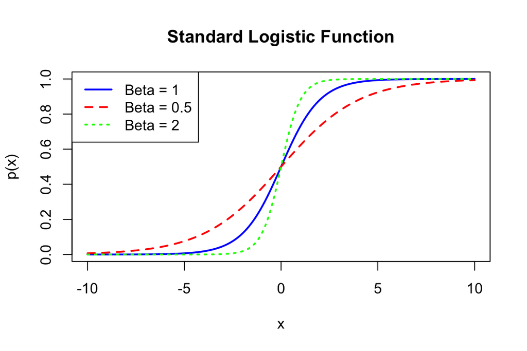

Notice how it “squashes” the predictions to stay within 0 and 1.

## Log-odds (Logit) connection

How does logistic regression connect to linear regression?

If we rearrange the logistic formula, we find that the **log-odds** is modeled linearly!

\[ \text{Odds} = \frac{p(\boldsymbol{x}_i)}{1 - p(\boldsymbol{x}_i)} = \frac{P(y_i=1|\boldsymbol{x}_i)}{P(y_i=0|\boldsymbol{x}_i)} \]

The logarithm of the odds is called the **logit** function: \[ \log\left(\frac{p(\boldsymbol{x}_i)}{1 - p(\boldsymbol{x}_i)}\right) = \beta_0 + \beta_1 x_{i1} + \dots + \beta_p x_{ip} \]

So, a generalized representation uses a *link function* — here, the logit link connects the mean (probability \(p(\boldsymbol{x}_i)\)) to the linear predictor: \(\beta_0 + \beta_1 x_{i1} + \dots + \beta_p x_{ip}\)

## Derivation of log odds from \(p(\boldsymbol{x}_i)\)

\[ \log\left(\frac{p(\boldsymbol{x}_i)}{1 - p(\boldsymbol{x}_i)}\right) = \beta_0 + \beta_1 x_{i1}\]

## Interpretation of Logistic Coefficients

In a linear regression model, a coefficient \(\beta_1\) means an increase of 1 in \(x_1\) leads to a \(\beta_1\) increase in \(E(y)\).

**What does** \(\beta_1\) mean in Logistic regression?

Looking at the log-odds equation: \[ \log(\text{Odds}) = \beta_0 + \beta_1 x_{1} \]

If we increase \(x_1\) by one unit:

- The **log-odds** increases by \(\beta_1\).

- The **odds** are multiplied by \(e^{\beta_1}\).

\(e^{\beta_1}\) is called the **Odds Ratio**.

## Derivation of Interpretations

Looking at the log-odds equation: \[ \log(\text{Odds}) = \beta_0 + \beta_1 x_{1} \]

## Parameter Estimation: Maximum Likelihood

In linear regression, we used the Least Squares method (which is equivalent to Maximum Likelihood for normally distributed errors) to find the best \(\beta\) coefficients.

For Logistic Regression, there is no analytical “formula” (like the least squares equations) for the coefficients.

Instead, the computer uses numerical algorithms to iteratively find the \(\beta\) values that maximize the **Likelihood function**. \[ L(\boldsymbol{\beta}) \rightarrow \text{max} \]

Maximizing the likelihood means finding the parameter values that make our observed binary data *most probable*.

## Likelihood Factorization

Since observations are independent, the total probability (Likelihood) of seeing our data is the product of individual probabilities.

For a Binomial/Bernoulli outcome \(y_i \in \{0, 1\}\), the probability is \(p_i\) if \(y_i=1\), and \((1-p_i)\) if \(y_i=0\).

We can write this elegantly as: \[ L(\boldsymbol{\beta}) = \prod_{i=1}^n p_i^{y_i} (1 - p_i)^{1 - y_i} \]

We want to find \(\boldsymbol\beta\) that maximizes this product (or its sum of logs!).

## How the computer finds the Maximum

Instead of a set formula, the computer takes “steps” uphill on the Log-Likelihood curve to find the peak!

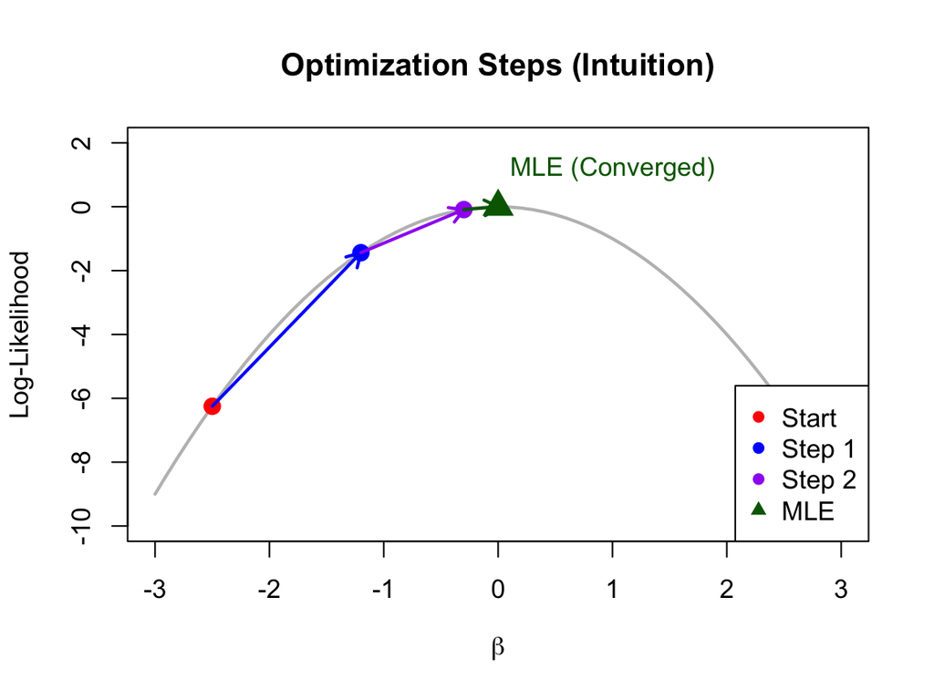

## The Wald Test

Just like linear regression, the maximum likelihood estimates \(\widehat{\beta}_j\) have standard errors, \(SE(\widehat{\beta}_j)\).

For large sample sizes, \(\widehat{\beta}_j\) approximately follows a normal distribution.

We can test the hypothesis for individual coefficients (\(H_0: \beta_j = 0\) vs \(H_A: \beta_j \neq 0\)) using the **Wald test**: \[ z = \frac{\widehat{\beta}_j - 0}{SE(\widehat{\beta}_j)} \]

This statistic \(z\) follows a Standard Normal distribution \(N(0,1)\). Software (like R) will output these \(z\)-values and corresponding p-values.

## Wald Test Decision Boundaries

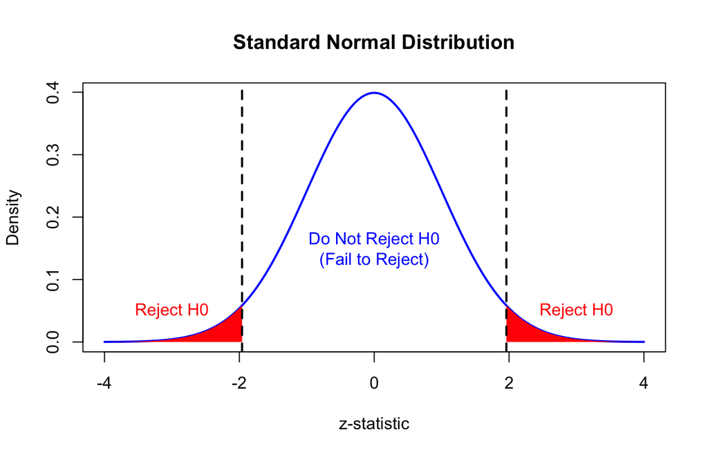

## Standard Errors from MLE Theory

How does the computer know the Standard Error (\(SE\)) of the estimates?

It uses the **curvature** of the log-likelihood peak!

- **Sharp peak:** We are very confident in the estimate. \(SE\) is small.
- **Flat peak:** There is a lot of uncertainty. \(SE\) is large.

The mathematical term is the **Fisher Information** (\(I\)), which measures the steepness (second derivative) of the peak.

\[ SE(\widehat{\beta}) = \sqrt{\frac{1}{I(\widehat{\beta})}} \]

So, sharp curvature = large Information = small Standard Error!

**The Motivation:** We want our proposed predictors to significantly reduce the Lack of Fit. Therefore, we want the **Residual Deviance** to be much smaller than the **Null Deviance**!

## Likelihood Ratio Test (Deviance)

To test if a subset of predictors as a whole is useful, we compare nested models using the **Likelihood Ratio Test (LRT)**.

This is analogous to comparing the Sum of Squared Errors (SSE) in ANOVA for linear models. Instead of SSE, we use **Deviance:** \(-2\log L(\boldsymbol{\beta})\).

- The Null Model contains only the intercept \(\beta_0\).
- The Proposed Model contains the predictors.

The test compares the Deviance of the models, and the difference in Deviances (\(\Delta \text{Deviance}\)) follows a \(\chi^2\) (Chi-square) distribution based on the number of additional predictors. Its degrees of freedom (\(df\)) is:

\[ df = (\text{parameters in Proposed}) - (\text{parameters in Null}) \]

## Likelihood Ratio Test (Intuition)

The Deviance compares the lack of fit of two models. If the Proposed Model is **much better**, its deviance is much lower, making the difference \(\Delta \text{Deviance}\) large!

- **Small difference:** The extra predictors don’t do much.
- **Large difference:** Pushes into the right tail (Rejection Region). The predictors are useful!

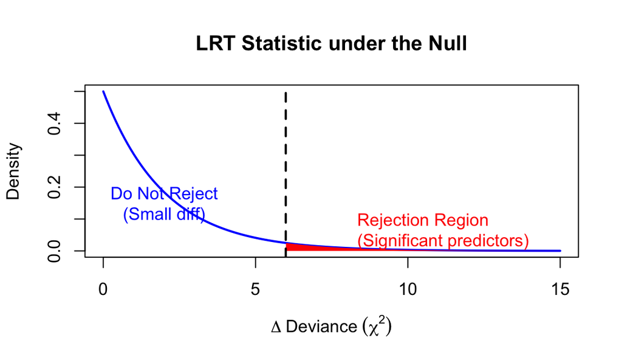

## Assumptions of Logistic Regression

Like linear models, GLMs have underlying assumptions we must check:

1. **Independence:** Observations \(y_i\) are independent of each other.
2. **Linearity in the Logit:** The log-odds (logit) relates *linearly* to the continuous predictors.
3. **No Multicollinearity:** Predictors shouldn’t be too perfectly correlated.
4. **No Extreme Outliers:** No single observation should unilaterally drive the model.
5. **No Overdispersion** (for Binomial data): The observed variance shouldn’t be higher than what the Binomial theory assumes.

## Example 1: Bird species on islands

Let’s test this in R! We look at the probability of a bird species being present on an island.

```
##   incidence  area isolation
## 1         1 7.928     3.317
## 2         0 1.925     7.554
## 3         1 2.045     5.883
## 4         0 4.781     5.932
## 5         0 1.536     5.308
## 6         1 7.369     4.934
```

- incidence = 1 if the species is present, 0 if absent
- area = Area of the island (\(km^2\))
- isolation = Distance to the mainland (\(km\))

Question: How does the probability of presence depend on the area?

## Fitting the Logistic Model in R

We use the `glm()` function, specifying `family=binomial(logit)` for logistic regression. `mixlm` package is used over the standard base R because it provides specific expanded summaries and visualizations in the context of the course, or we can just use the base `glm`.

```r
library(mixlm)
GLM.1 <- glm(incidence ~ area, family=binomial(logit), data=island)
summary(GLM.1)
```

## The output

```
##
## Call:
## glm(formula = incidence ~ area, family = binomial(logit), data = island)
##
## Coefficients:
##             Estimate Std. Error z value Pr(>|z|)
## (Intercept)  -2.1554     0.7545  -2.857 0.004278 **
## area          0.6272     0.1861   3.370 0.000753 ***
## ---
## Signif. codes:  0 '***' 0.001 '**' 0.01 '*' 0.05 '.' 0.1 ' ' 1
##
## (Dispersion parameter for binomial family taken to be 1)
##
##     Null deviance: 68.029  on 49  degrees of freedom
## Residual deviance: 50.172  on 48  degrees of freedom
## AIC: 54.172
##
## Number of Fisher Scoring iterations: 5
```

## Interpreting the output

- Intercept \(\widehat{\beta}_0 = -2.16\)
- Area coefficient \(\widehat{\beta}_{\text{area}} = 0.63\). The positive coefficient means larger area increases the odds of bird presence!
- The **p-value** is \(<0.001\), found using the Wald test (z value = \(3.370\)). The coefficient is significantly different from 0.
- **Odds ratio**: \(e^{0.63} \approx 1.872\). For every 1 \(km^2\) increase in area, the odds of the species being present on the island increase by about \(87.2\%\).

## Graphical Representation of the Fit

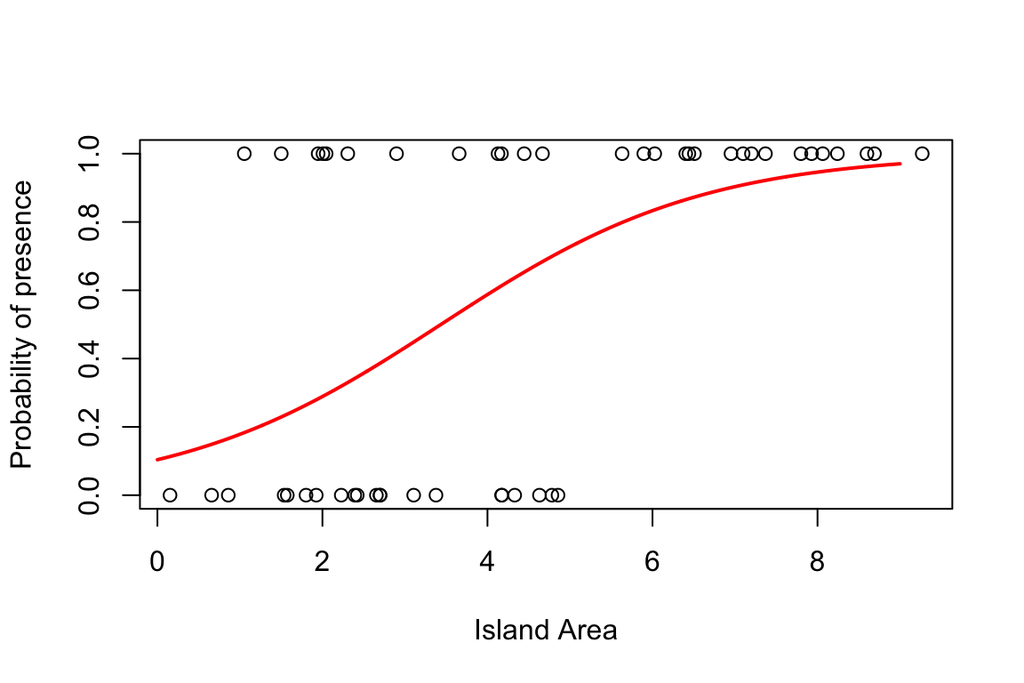

```r
xv <- seq(0,9,0.01)
yv <- predict(GLM.1, list(area=xv), type="response")
plot(island$area, island$incidence, ylab="Probability of presence", xlab="Island Area")
lines(xv, yv, col="red", lwd=2)
```

## Goodness of fit (LRT): Area against the `Null`

`anova()` function with `test="LR"` or `test="Chisq"`.

```r
anova(GLM.1, test='LR')
```

```
## Analysis of Deviance Table
##
## Model: binomial, link: logit
##
## Response: incidence
##
## Terms added sequentially (first to last)
##
##
##      Df Deviance Resid. Df Resid. Dev  Pr(>Chi)
## NULL                    49     68.029
## area  1   17.857        48     50.172 2.382e-05 ***
## ---
## Signif. codes:  0 '***' 0.001 '**' 0.01 '*' 0.05 '.' 0.1 ' ' 1
```

## Goodness of fit (LRT) cont.

The Likelihood Ratio test from the previous output shows a significant result: p-value<\(0.05\).

This indicates that adding the `area` predictor significantly improves the fit of the model compared to a simple baseline model with just the intercept.

## Expanding the model

What if we also include isolation?

```
##
## Call:
## glm(formula = incidence ~ area + isolation, family = binomial(logit),
##     data = island)
##
## Coefficients:
##             Estimate Std. Error z value Pr(>|z|)
## (Intercept)   6.6417     2.9218   2.273  0.02302 *
## area          0.5807     0.2478   2.344  0.01909 *
## isolation    -1.3719     0.4769  -2.877  0.00401 **
## ---
## Signif. codes:  0 '***' 0.001 '**' 0.01 '*' 0.05 '.' 0.1 ' ' 1
##
## (Dispersion parameter for binomial family taken to be 1)
##
##     Null deviance: 68.029  on 49  degrees of freedom
## Residual deviance: 28.402  on 47  degrees of freedom
## AIC: 34.402
##
## Number of Fisher Scoring iterations: 6
```

Isolation has a negative coefficient: larger distance from mainland decreases the probability of the species being present!

## Goodness of fit (LRT)

Comparing the models progressively:

```r
anova(GLM.2, test='LR')
```

```
## Analysis of Deviance Table
##
## Model: binomial, link: logit
##
## Response: incidence
##
## Terms added sequentially (first to last)
##
##
##           Df Deviance Resid. Df Resid. Dev  Pr(>Chi)
## NULL                         49     68.029
## area       1   17.857        48     50.172 2.382e-05 ***
## isolation  1   21.770        47     28.402 3.073e-06 ***
## ---
## Signif. codes:  0 '***' 0.001 '**' 0.01 '*' 0.05 '.' 0.1 ' ' 1
```

Both variables give significant drops in deviance.

## Comparing Models: The AIC

The **Akaike’s Information Criterion (AIC)** is commonly used to compare models. It is defined as:

\[-2 \times \log L(\boldsymbol{\beta}) + 2 \times p\]

where \(\log L(\boldsymbol{\beta})\) is the log-likelihood of the model and \(p\) is the number of estimated parameters. It penalizes complex models. **Smaller is better**.

## Comparing Models: The AIC (Results)

```r
AIC(GLM.1) # Area only
```

```
## [1] 54.17231
```

```r
AIC(GLM.2) # Area + Isolation
```

```
## [1] 34.40216
```

Adding isolation improves the model significantly, leading to a lower AIC!

## Comparing Models: BIC

Along with AIC, we also use the **Bayesian Information Criterion (BIC)**: \[ -2 \times \log L(\boldsymbol{\beta}) + \log(n) \times p \] BIC penalizes complex models even more harshly than AIC because \(\log(n)\) is usually greater than \(2\). Again, **smaller is better**.

```r
BIC(GLM.1) # Area only
```

```
## [1] 57.99636
```

```r
BIC(GLM.2) # Area + Isolation
```

```
## [1] 40.13823
```

Both AIC and BIC agree: adding isolation improves the model!

## Checking the Bird Model (Diagnostics)

Let’s verify our assumptions by generating all standard diagnostic plots for `GLM.2`:

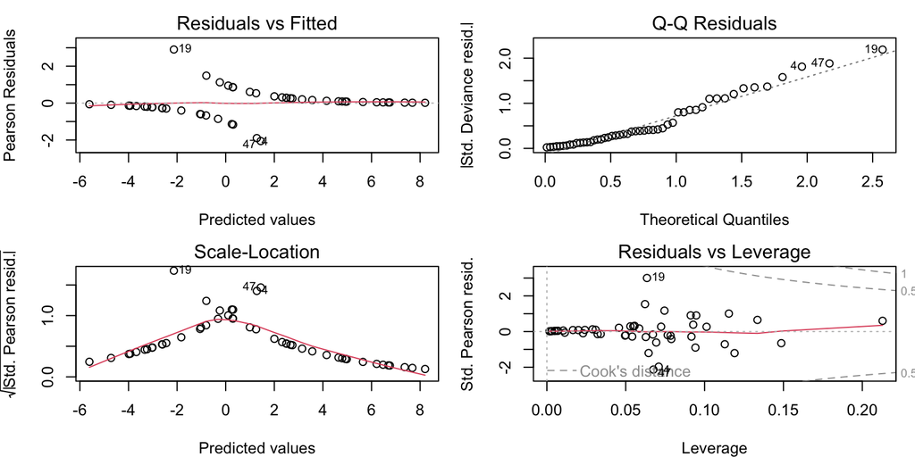

```r
par(mfrow=c(2,2), mar=c(4,4,2,1))
plot(GLM.2)
```

## Binomial response

Sometimes, rather than tracking individual 0s and 1s, we have binomial data.

\[ y_i \text{ successes out of } n_i \text{ trials}\] For \(i = 1,\ldots, n\) where \(y_i\) is the number of ‘successes’ among \(n_i\) total experiments in group \(i\).

We assume \(y_i \sim \text{Binomial}(n_i, p_i)\).

## Binomial response (cont.)

We can use logistic regression to model \(p_i\) using predictors, functioning precisely the same way!

## Example 2: The insect sex data

The sex counts in insects (proportion males) depending on population density:

```
##   density females males
## 1       1       1     0
## 2       4       3     1
## 3      10       7     3
## 4      22      18     4
## 5      55      22    33
## 6     121      41    80
## 7     210      52   158
## 8     444      79   365
```

## Binomial regression in R

In RStudio, the response for Binomial grouped data must be an array of `successes` and `failures`.

In the model specification, use `cbind(succesess, failures)` as the response variable.

```r
GLM.4 <- glm(cbind(males, females) ~ log(density),
             family=binomial(logit), data=numbers)
```

## Insect sex-ratio model summary

```
##
## Call:
## glm(formula = cbind(males, females) ~ log(density), family = binomial(logit),
##     data = numbers)
##
## Coefficients:
##              Estimate Std. Error z value Pr(>|z|)
## (Intercept)  -2.65927    0.48758  -5.454 4.92e-08 ***
## log(density)  0.69410    0.09056   7.665 1.80e-14 ***
## ---
## Signif. codes:  0 '***' 0.001 '**' 0.01 '*' 0.05 '.' 0.1 ' ' 1
##
## (Dispersion parameter for binomial family taken to be 1)
##
##     Null deviance: 71.1593  on 7  degrees of freedom
## Residual deviance:  5.6739  on 6  degrees of freedom
## AIC: 38.201
##
## Number of Fisher Scoring iterations: 4
```

## Insect sex-ratio plot

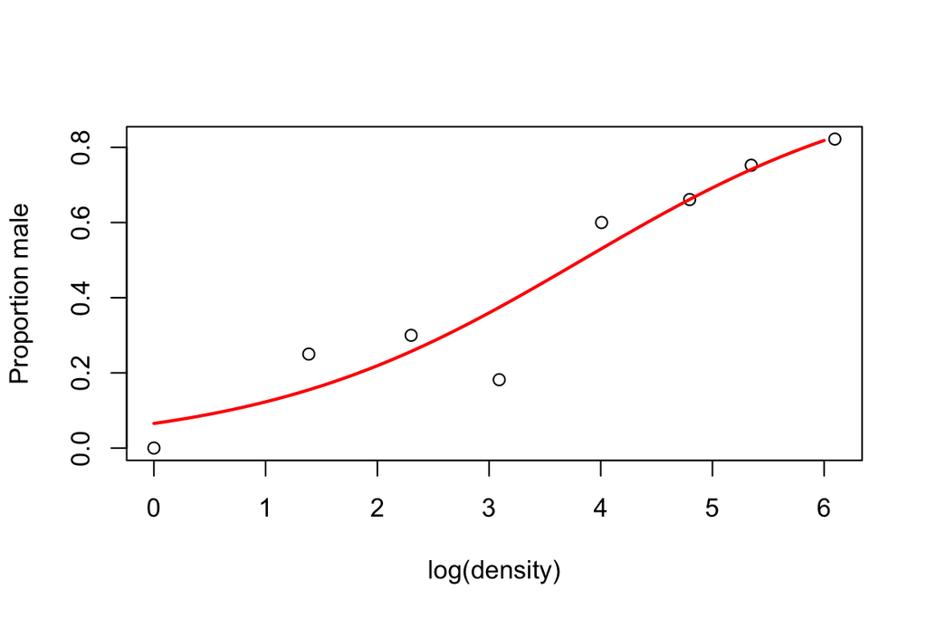

## Binary classification revisited

Remember from Multivariate Analysis: Assume we have two groups (classes), \(c_1\) and \(c_2\). By Bayes rule, the posterior probability of class 2 given observed variables is:

\[ P(c_2 | x_1,\dots, x_k) \propto f(x_1,\dots, x_k | c_2) P(c_2) \]

Logistic regression gives an alternative, **direct** method to estimate this posterior probability!

Define \(y=1\) for \(c_2\) and \(y=0\) for \(c_1\). Then logistic regression directly estimates: \[ P(c_2 | x_1,\dots, x_k) = P(y=1 | x_1,\dots, x_k) = \frac{e^{ \beta_0 + \beta_1 x_1 + \dots}}{1 + e^{ \beta_0 + \beta_1 x_1 + \dots}} \]

We classify to class 2 if the estimated \(P(y=1 | x_1,\dots, x_k) > 0.5\).

## Example 3: Lizards

Can we discriminate the Sex of Lizards based on Mass? Let \(y=1\) if female, \(y=0\) if male.

```
##              Estimate Std. Error   z value   Pr(>|z|)
## (Intercept)  7.549321  3.0619963  2.465490 0.01368261
## Mass        -0.890471  0.3551573 -2.507258 0.01216720
```

For every 1 unit increase in Mass, the log-odds of being female changes by \(-0.89\). Thus heavier lizards are more likely to be male!

## Lizards: Fitted line plot

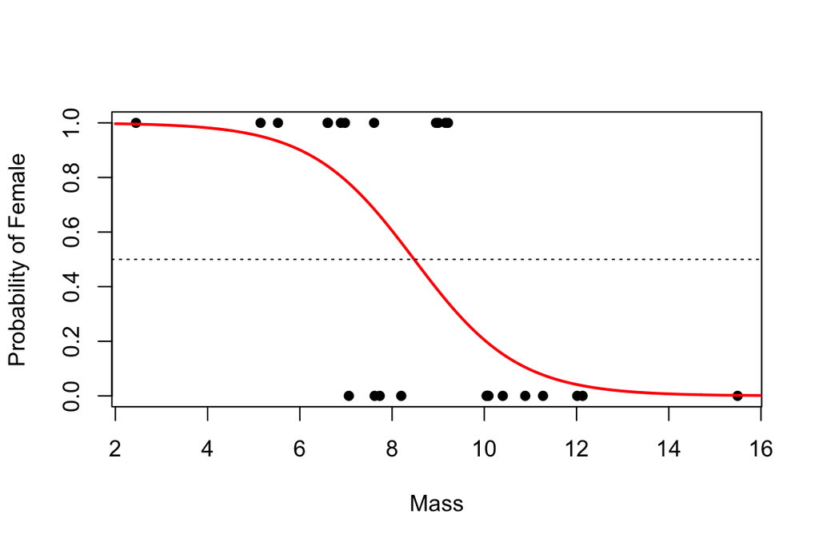

## Classify a new lizard

Assume we have measured a new lizard with mass 5g. What is the most probable gender for this lizard given our estimated model?

```r
new_lizard_data <- data.frame(Mass = 5)
ypred <- predict(model, new_lizard_data, type="response")
ypred
```

```
##         1
## 0.9567674
```

This returns the fitted estimated probability of being female (\(y=1\)).

Since \(0.957 > 0.5\), we classify the lizard to the female class. Hence, a lizard of Mass 5g is most probably a female.

## Lizards: Variable Selection

Let’s include all predictors (`Mass`, `SVL` - Snout-vent length, `HLS` - Hind limb span) and perform stepwise selection!

```r
full_model <- glm(y ~ Mass + SVL + HLS, family=binomial, data=Lizard)
selected_model <- step(full_model, direction="both", trace=0,k = 2)
summary(selected_model)$coef
```

```
##               Estimate Std. Error      z value  Pr(>|z|)
## (Intercept) 1764.01091 1128477.11  0.001563178 0.9987528
## HLS          -13.78172    8820.73 -0.001562424 0.9987534
```

The stepwise method selected only `HLS` as the best predictor (lowest AIC).

## Lizards: Out of sample evaluation

Let’s measure how well our model really works by splitting data into a **training set** and a **test set**.

```r
set.seed(42)
train_idx <- sample(1:nrow(Lizard), size = 0.6 * nrow(Lizard))
train_data <- Lizard[train_idx, ]
test_data <- Lizard[-train_idx, ]

# Fit on training data
train_model <- glm(ifelse(Sex=="m", 0, 1) ~ HLS,
                   family=binomial, data=train_data)
```

## Lizards: Training sample accuracy

First, let’s evaluate the model on the **training data**:

```r
train_probs <- predict(train_model, train_data, type="response")
train_preds <- ifelse(train_probs > 0.5, 1, 0)
train_actuals <- ifelse(train_data$Sex=="m", 0, 1)

# Training Confusion Matrix
table(Predicted = train_preds, Actual = train_actuals)
```

```
##          Actual
## Predicted 0 1
##         0 7 0
##         1 0 8
```

Training Accuracy: 1

## Lizards: Testing sample accuracy

```r
test_probs <- predict(train_model, test_data, type="response")
test_preds <- ifelse(test_probs > 0.5, 1, 0)
test_actuals <- ifelse(test_data$Sex=="m", 0, 1)

# Test Confusion Matrix
table(Predicted = test_preds, Actual = test_actuals)
```

```
##          Actual
## Predicted 0 1
##         0 6 0
##         1 0 4
```

Test Accuracy: 1